# Test a Perceptual Phenomenon

### Analyzing the Stroop Effect

Perform the analysis in the space below. Remember to follow [the instructions](https://docs.google.com/document/d/1-OkpZLjG_kX9J6LIQ5IltsqMzVWjh36QpnP2RYpVdPU/pub?embedded=True) and review the [project rubric](https://review.udacity.com/#!/rubrics/71/view) before submitting. Once you've completed the analysis and write up, download this file as a PDF or HTML file and submit in the next section.

(1) What is the independent variable? What is the dependent variable?

The independent variable of this Stroop test Experiment is 'Word Condtion' (Congruent and Non-Congruent).

The dependant varibale for this experiment is the 'Reaction Time for Participants'. As this varies from user to user, when we manipulate the independent varibale 'Word Condition' from Congruent to Non-Congruent.

Note:'Reaction Time for Participants': Is defined as overall time taken by each member participating in the study, to 'correctly' read the 'color' of the 'Word Condition(s)', not the 'text' in each 'Word Condition'. Which is captured in the datasheet(stroopdata.csv) of the experiment.

Sources: The definitions and clarifications about the expermient were understood from Faculty of Washington Website https://faculty.washington.edu/chudler/words.html and Wikipedia: https://en.wikipedia.org/wiki/Stroop_effect.

(2) What is an appropriate set of hypotheses for this task? What kind of statistical test do you expect to perform? Justify your choices.

2A: The following will be the Hypothesis for this task:

H$_0$ (Null Hypothesis): Changing 'Word Condition' from Congruent to Non-Congruent doesn't impact 'Raction Time for Particpants' in a statistically significant way. (confidence internal 95%) Equation:- Average Reaction Time (congruent) = Aevrage Reaction Time (incongruent) without much variability

H$_1$ (Alternate Hypothesis): Chnaging 'Word Condition' from Congrument to Non-Congruent will increase 'Reation time for Participants' in a statisticaly significant way. (confidence interval 95%) Equation:- Average Reaction Time (congruent) < Aevrage Reaction Time (incongruent) with significant variability

2B: Statistically test to proove or reject the H$_0$ (null hypothesis), will be a paried one-tail t-Test, as the samples are from same individuals and with different condtions on the independent varibale 'Word Condition' Congruent/Non-Congruent.

##### More justification provided here.

t-Test is the perfect test in this scenario as we have a sample size of 24, which is less than 30 and we don't know the mean of the population so z-Test can't be performed here. And f-Test can't be performed as we don't know the population are noramlly distibuted here and don't know if the samples are drawn randomly from the population.

A t-Test in this condition will help us understand if there is a significant difference in the varibality of data to draw conslusions on Reaction time being dependant on Word Condition or not. The confidence variable is selected as 95%, as with any standard scientific study, but once we draw observations we can continue to increase the confidence varibale to check for singificance at different $\alpha$ levels = 0.95/0.99/0.999.

This is a one tailed t-Test, due to assumption on that the incongrument conditon requires more prcoessing time in our brains due to the mixing of the color and text of Words.

#### This is further explained by the theories prososed by 'Faculty of Washington Website https://faculty.washington.edu/chudler/words.html':

##### "The words themselves have a strong influence over your ability to say the color. The interference between the different information (what the words say and the color of the words) your brain receives causes a problem. There are two theories that may explain the Stroop effect:

##### 1. Speed of Processing Theory: the interference occurs because words are read faster than colors are named.

##### 2. Selective Attention Theory: the interference occurs because naming colors requires more attention than reading words."

So, for the t-Test and hypothesis summary:

H$_0$: $ \mu_{con} $ = $ \mu_{incon} $, $\alpha$ = 0.95, df= sample-1 =24-1 =23, t$_{stat}$ <= t$_{critical}$ (0.95, df=23)

H$_1$: $ \mu_{con} $ < $ \mu_{incon} $, $\alpha$ = 0.95, df= sample-1 =24-1 =23, t$_{stat}$ > t$_{critical}$ (0.95, df=23)

(3) Report some descriptive statistics regarding this dataset. Include at least one measure of central tendency and at least one measure of variability. The name of the data file is 'stroopdata.csv'.

```python
# Perform the analysis here
import pandas as pd

df = pd.read_csv('stroopdata.csv')
#print(df.head())

#Congruent
dfcon = df[df.columns[0]]
#print(dfcon.head())

#measures of variability
mean_con = dfcon.mean()
mode_con = dfcon.mode()
median_con = dfcon.median()

#Applying Bessesl's correction as this is a sample sd.
sd_con = dfcon.std(ddof=1)
var_con = dfcon.var()
iqr_con = dfcon.quantile(0.75)-dfcon.quantile(0.25)

print('Measures of Central Tencdency for Congruent Data\n')
print('Mean:',round(mean_con,4))
#print('Mode of Congruent:',round(mode_con,4))
print('Median:',round(median_con,4))

print('\nMeasures of Measures of Varibaility for Congruent Data\n')
print('Inter Quartile Range:',round(iqr_con,4))
print('Standard Deviation:',round(sd_con,4))
print('Variance of Congruent:',round(var_con,4))

#InCongruent
dfincon = df[df.columns[1]]
#print(dfincon.head())

#measures of variability
mean_incon = dfincon.mean()
mode_incon = dfincon.mode()
median_incon = dfincon.median()

#Applying Bessesl's correction as this is a sample sd.
sd_incon = dfincon.std(ddof=1)
var_incon = dfincon.var()
iqr_incon = dfincon.quantile(0.75)-dfincon.quantile(0.25)

print('\nMeasures of Central Tencdency for In-Congruent Data\n')
print('Mean:',round(mean_incon,4))
#print('Mode of Congruent:',round(mode_con,4))
print('Median:',round(median_incon,4))

print('\nMeasures of Measures of Varibaility for In-Congruent Data\n')
print('Inter Quartile Range:',round(iqr_incon,4))
print('Standard Deviation:',round(sd_incon,4))
print('Variance:',round(var_incon,4))
```

```
Measures of Central Tencdency for Congruent Data

Mean: 14.0511
Median: 14.3565

Measures of Measures of Varibaility for Congruent Data

Inter Quartile Range: 4.3055
Standard Deviation: 3.5594
Variance of Congruent: 12.669

Measures of Central Tencdency for In-Congruent Data

Mean: 22.0159
Median: 21.0175

Measures of Measures of Varibaility for In-Congruent Data

Inter Quartile Range: 5.3347
Standard Deviation: 4.7971
Variance: 23.0118
```

Please find all the measures of Central tendency and Variability above. However, there is no mode for the data sets, as there are no two data sets with the same frequency.

(4) Provide one or two visualizations that show the distribution of the sample data. Write one or two sentences noting what you observe about the plot or plots.

```
Congruent Dataset Normal Distribution curve
"X Axis Reaction Time in seconds Y Axis Frequency"
```

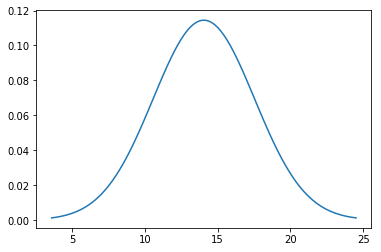

```
In-Congruent Dataset Normal Distribution curve
"X Axis Reaction Time in seconds Y Axis Frequency"
```

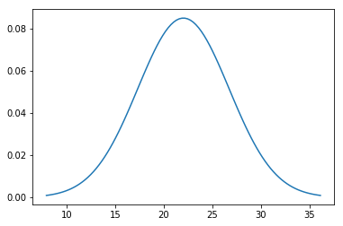

```
Box Plot for Congruent vs Incongruent
"Y Axis Reaction time in Seconds"
```

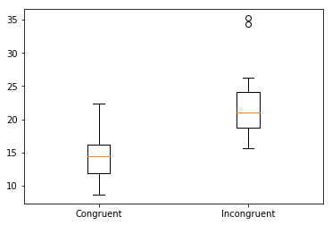

```python
# Build the visualizations here
import pandas as pd
import numpy as np
import matplotlib.pyplot as plt
import matplotlib.mlab as mlab

df = pd.read_csv('stroopdata.csv')
#print(df.head())

#Congruent
dfcon = df[df.columns[0]]
dfincon = df[df.columns[1]]

mean_con = dfcon.mean()

print('Congruent Dataset Normal Distribution curve \n"X Axis Reaction Time in seconds Y Axis Frequency"')
sd_con = dfcon.std(ddof=0)
var_con = dfcon.var()
plot_con = np.linspace(mean_con-3*sd_con,mean_con+3*sd_con,num=100)
plt.plot(plot_con,mlab.normpdf(plot_con,mean_con,sd_con))
plt.show()

print('In-Congruent Dataset Normal Distribution curve \n"X Axis Reaction Time in seconds Y Axis Frequency"')
sd_incon = dfincon.std(ddof=0)
var_incon = dfincon.var()
plot_incon = np.linspace(mean_incon-3*sd_incon,mean_incon+3*sd_incon,num=100)
plt.plot(plot_incon,mlab.normpdf(plot_incon,mean_incon,sd_incon))
plt.show()

print('Box Plot for Congruent vs Incongruent \n"Y Axis Reaction time in Seconds"')
plt.boxplot([dfcon,dfincon],labels=['Congruent','Incongruent'])
plt.show()
```

As demosntrated, by the above Normal distributions above of the Congruent and In-Congruent data we can visualize the difference between the datasets. Namely for Congruent Dataset the highest number of people completed the test in between 10-20 seconds, higest being close to 15 seconds. For Incongruent Dataset the highest number of people completed the test in between 15-30 seconds, higest being close to 22 seconds.

The second visualization is much more clearer in comparing the two datasets, we can see that people took longer to complete the Incongruent test than the congruent test. This can be seen by the Reaction time for majority of the poeple being higher in the Incongruent Test.

(5) Now, perform the statistical test and report the results. What is the confidence level and your critical statistic value? Do you reject the null hypothesis or fail to reject it? Come to a conclusion in terms of the experiment task. Did the results match up with your expectations?

```python
# Perform the statistical test here
import scipy.stats as st

#this would be a two tailed test with Two Related Samples
ttest = st.ttest_rel(dfincon,dfcon,axis=0)
print('\nTwo Tailed Values:', ttest)

#converting two test results to real t-stat and p-value
real_tstat = ttest[0]
real_pval = (ttest[1]/2)

print('Real t-stat value:',real_tstat, '\nReal pvalue:',real_pval)
print('Critical Value:',st.t.ppf(1-0.05,23))
```

```
Two Tailed Values: Ttest_relResult(statistic=8.020706944109957, pvalue=4.1030005857111781e-08)
Real t-stat value: 8.02070694411
Real pvalue: 2.05150029286e-08
Critical Value: 1.71387152775
```

So, According to the results calculated above we can see that, the t-stat for our Paried one tailed t-test came out to be 8.02, and the t-critical is 1.71, so t$_{stat}$ > t$_{critical}$, so for this Right side one-tail t-Test, the t$_{stat}$ is greater than t$_{critical}$, which means this value falls in the critical region, so we can reject null hypothesis H$_{0}$ based on this.

And the p-value is nearly 0, so the p$_{val}$ < $\alpha$$_{0.95}$.

Conclusion: We can say that the 'Reaction Time' of participants is more for 'Incongruent' data recognition than the 'Congruent' data. In other words, poeple take longer consistently average time(22.0159 seconds) to perform Stroop's Test om Incongruent data compaired to Congruent data average time(14.0511 seconds).

The rsults, were as per expectations, as the proposed diffculties stated in Section 2B.